# BAN614 Winter 2023: Final Project

*Observations:* The best model was *Default_lda* ## Model with these as predictor variable; ## Dependents , Tenure , PhoneService , MultipleLines , InternetService , OnlineSecurity , OnlineBackup , DeviceProtection , TechSupport , StreamingTV , StreamingMovies , Contract , PaperlessBilling , PaymentMethod , MonthlyCharges , TotalCharges

```r
## Defining the model
Default_lda2 <- lda(Status ~ Dependents + Tenure + PhoneService + MultipleLines + InternetService + OnlineSecurity + OnlineBackup + DeviceProtection + TechSupport + StreamingTV + StreamingMovies + Contract + PaperlessBilling + PaymentMethod + MonthlyCharges + TotalCharges, data = df.train)
Default_lda
```

```
Call:
lda(Status ~ Gender + SeniorCitizen + Partner + Dependents +
    Tenure + PhoneService + MultipleLines + InternetService +
    OnlineSecurity + OnlineBackup + DeviceProtection + TechSupport +
    StreamingTV + StreamingMovies + Contract + PaperlessBilling +
    PaymentMethod + MonthlyCharges + TotalCharges, data = df.train)

Prior probabilities of groups:
  Current      Left
0.7303571 0.2696429

Group means:
        GenderMale SeniorCitizen1 PartnerYes DependentsYes   Tenure PhoneServiceYes MultipleLinesNo phone service MultipleLinesYes InternetServiceFiber optic InternetServiceNo OnlineSecurityNo internet service OnlineSecurityYes
Current  0.5083130      0.1312958  0.5310513     0.3496333 37.62054        0.902934                    0.09706601        0.4110024                  0.3501222         0.2743276                         0.2743276         0.3320293
Left     0.4986755      0.2609272  0.3529801     0.1715232 18.10662        0.910596                    0.08940397        0.4490066                  0.6933775         0.0615894                         0.0615894         0.1536424
        OnlineBackupNo internet service OnlineBackupYes DeviceProtectionNo internet service DeviceProtectionYes TechSupportNo internet service TechSupportYes StreamingTVNo internet service StreamingTVYes StreamingMoviesNo internet service
Current                       0.2743276       0.3699267                           0.2743276           0.3594132                      0.2743276      0.3356968                      0.2743276      0.3674817                          0.2743276
Left                          0.0615894       0.2774834                           0.0615894           0.2913907                      0.0615894      0.1688742                      0.0615894      0.4377483                          0.0615894
        StreamingMoviesYes ContractOne year ContractTwo year PaperlessBillingYes PaymentMethodCredit card (automatic) PaymentMethodElectronic check PaymentMethodMailed check MonthlyCharges TotalCharges
Current          0.3687042       0.25085575       0.31931540           0.5352078                            0.2545232                     0.2493888                 0.2491443       61.32687     2553.577
Left             0.4397351       0.09072848       0.02649007           0.7483444                            0.1158940                     0.5754967                 0.1655629       74.43023     1548.337

Coefficients of linear discriminants:
                                               LD1
GenderMale                           -0.0155871185
SeniorCitizen1                        0.1875804273
PartnerYes                           -0.0341481971
DependentsYes                        -0.1224496155
Tenure                               -0.0106380734
PhoneServiceYes                      -0.1224374500
MultipleLinesNo phone service         0.1224374500
MultipleLinesYes                      0.2425690784
InternetServiceFiber optic            0.7861201964
InternetServiceNo                    -0.0935184099
OnlineSecurityNo internet service    -0.0935184099
OnlineSecurityYes                    -0.2991871368
OnlineBackupNo internet service      -0.0935184099
OnlineBackupYes                      -0.1201547777
DeviceProtectionNo internet service  -0.0935184099
DeviceProtectionYes                  -0.0116473734
TechSupportNo internet service       -0.0935184099
TechSupportYes                       -0.2604211380
StreamingTVNo internet service       -0.0935184099
StreamingTVYes                        0.1775665189
StreamingMoviesNo internet service   -0.0935184099
StreamingMoviesYes                    0.2271890199
ContractOne year                     -0.5048148786
ContractTwo year                     -0.3484916483
PaperlessBillingYes                   0.2277576278
PaymentMethodCredit card (automatic) -0.1027930181
PaymentMethodElectronic check         0.3306786935
PaymentMethodMailed check            -0.0553735159
MonthlyCharges                        0.0032672328
TotalCharges                         -0.0002019895
```

```r
## Confusion matrix
### Making predictions

Default_pred2 <- predict(Default_lda2,df.test)
head(Default_pred2$posterior)
```

```
     Current       Left
1  0.4698285 0.53017152
2  0.9539968 0.04600317
3  0.7611494 0.23885060
5  0.2290614 0.77093863
11 0.8229330 0.17706698
21 0.3455667 0.65443327
```

```r
### Make confusion matrix
Default_conf_matrix2 <- confusionMatrix(Default_pred2$class, df.test$Status, positive = "Left")
Default_conf_matrix2
```

```
Confusion Matrix and Statistics

          Reference
Prediction Current Left
   Current     931  153
   Left        122  193

               Accuracy : 0.8034
                 95% CI : (0.7816, 0.824)
    No Information Rate : 0.7527
    P-Value [Acc > NIR] : 0.000003828

                  Kappa : 0.4556

 Mcnemar's Test P-Value : 0.07044

            Sensitivity : 0.5578
            Specificity : 0.8841
         Pos Pred Value : 0.6127
         Neg Pred Value : 0.8589
             Prevalence : 0.2473
         Detection Rate : 0.1380
   Detection Prevalence : 0.2252
      Balanced Accuracy : 0.7210

       'Positive' Class : Left
```

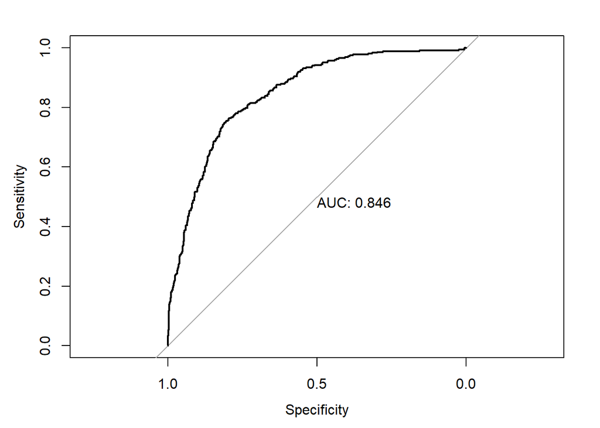

```
Call:
roc.default(response = Default_thresholds$Actual_defaults, predictor = Default_thresholds2$Probability_Left2,     plot = TRUE, print.auc = TRUE)

Data: Default_thresholds2$Probability_Left2 in 1053 controls (Default_thresholds$Actual_defaults Current) < 346 cases (Default_thresholds$Actual_defaults Left).
Area under the curve: 0.8463
```

```r
## Plot ROC baesd on threshold of 0.5

# We can do it by accessing the list object *Default_pred*. We first use the name *posterior* within bouble braces to access the matrix and then refer to the second column of the matrix using the square brackets.

Probability_Left2 <- Default_pred2[["posterior"]][,2]

# * We then save it as a dataframe and then also add the actual default values from the original dataset.

Default_thresholds2 <- data.frame(Probability_Left2)
Default_thresholds$Actual_defaults <- df.test$Status

# We now add another column and assign classes based on the threshold of 50%. If the posterior is > 0.5 then we assign a "Left" , else "Current".

Default_thresholds2 <- Default_thresholds2 %>%
  mutate(Class_th_0.5 = ifelse(Probability_Left2 > 0.5, "Left", "Current"), Class_th_0.5 = factor(Class_th_0.5, levels=c("Left", "Current")))

roc(Default_thresholds$Actual_defaults,Default_thresholds2$Probability_Left2,plot=TRUE,print.auc=TRUE)
```

## Model with these as predictor variable;

## Gender , SeniorCitizen , Partner , Dependents , Tenure , PhoneService , MultipleLines , InternetService , OnlineSecurity , OnlineBackup , DeviceProtection , TechSupport , StreamingTV , StreamingMovies , Contract , PaperlessBilling

```r
## Defining the model
Default_lda3 <- lda(Status ~ Gender + SeniorCitizen + Partner + Dependents + Tenure + PhoneService + MultipleLines + InternetService + OnlineSecurity + OnlineBackup + DeviceProtection + TechSupport + StreamingTV + StreamingMovies + Contract + PaperlessBilling  , data = df.train)
Default_lda3
```

```
Call:
lda(Status ~ Gender + SeniorCitizen + Partner + Dependents +
    Tenure + PhoneService + MultipleLines + InternetService +
    OnlineSecurity + OnlineBackup + DeviceProtection + TechSupport +
    StreamingTV + StreamingMovies + Contract + PaperlessBilling,
    data = df.train)

Prior probabilities of groups:
  Current      Left
0.7303571 0.2696429

Group means:
        GenderMale SeniorCitizen1 PartnerYes DependentsYes   Tenure PhoneServiceYes MultipleLinesNo phone service MultipleLinesYes InternetServiceFiber optic InternetServiceNo OnlineSecurityNo internet service OnlineSecurityYes
Current  0.5083130      0.1312958  0.5310513     0.3496333 37.62054        0.902934                    0.09706601        0.4110024                  0.3501222         0.2743276                         0.2743276         0.3320293
Left     0.4986755      0.2609272  0.3529801     0.1715232 18.10662        0.910596                    0.08940397        0.4490066                  0.6933775         0.0615894                         0.0615894         0.1536424
        OnlineBackupNo internet service OnlineBackupYes DeviceProtectionNo internet service DeviceProtectionYes TechSupportNo internet service TechSupportYes StreamingTVNo internet service StreamingTVYes StreamingMoviesNo internet service
Current                       0.2743276       0.3699267                           0.2743276           0.3594132                      0.2743276      0.3356968                      0.2743276      0.3674817                          0.2743276
Left                          0.0615894       0.2774834                           0.0615894           0.2913907                      0.0615894      0.1688742                      0.0615894      0.4377483                          0.0615894
        StreamingMoviesYes ContractOne year ContractTwo year PaperlessBillingYes
Current          0.3687042       0.25085575       0.31931540           0.5352078
Left             0.4397351       0.09072848       0.02649007           0.7483444

Coefficients of linear discriminants:
                                            LD1
GenderMale                          -0.02085115
SeniorCitizen1                       0.21987113
PartnerYes                          -0.02717424
DependentsYes                       -0.13095806
Tenure                              -0.02362792
PhoneServiceYes                     -0.16442171
MultipleLinesNo phone service        0.16442171
MultipleLinesYes                     0.21865579
InternetServiceFiber optic           0.76741972
InternetServiceNo                   -0.10743420
OnlineSecurityNo internet service   -0.10743420
OnlineSecurityYes                   -0.39720591
OnlineBackupNo internet service     -0.10743420
OnlineBackupYes                     -0.20446498
DeviceProtectionNo internet service -0.10743420
DeviceProtectionYes                 -0.09144542
TechSupportNo internet service      -0.10743420
TechSupportYes                      -0.36445140
StreamingTVNo internet service      -0.10743420
StreamingTVYes                       0.14593675
StreamingMoviesNo internet service  -0.10743420
StreamingMoviesYes                   0.19488433
ContractOne year                    -0.55744281
ContractTwo year                    -0.37598145
PaperlessBillingYes                  0.25613505
```

```r
## Confusion matrix
### Making predictions

Default_pred3 <- predict(Default_lda3,df.test)
head(Default_pred3$posterior)
```

```
     Current      Left
1  0.4915605 0.5084395
2  0.9528699 0.0471301
3  0.7297840 0.2702160
5  0.2834684 0.7165316
11 0.7839235 0.2160765
21 0.3160757 0.6839243
```

```r
### Make confusion matrix
Default_conf_matrix3 <- confusionMatrix(Default_pred3$class, df.test$Status, positive = "Left")
Default_conf_matrix3
```

```
Confusion Matrix and Statistics

          Reference
Prediction Current Left
   Current     948  155
   Left        105  191

               Accuracy : 0.8142
                 95% CI : (0.7928, 0.8342)
    No Information Rate : 0.7527
    P-Value [Acc > NIR] : 0.0000000237

                  Kappa : 0.4754

 Mcnemar's Test P-Value : 0.002375

            Sensitivity : 0.5520
            Specificity : 0.9003
         Pos Pred Value : 0.6453
         Neg Pred Value : 0.8595
             Prevalence : 0.2473
         Detection Rate : 0.1365
   Detection Prevalence : 0.2116
      Balanced Accuracy : 0.7262

       'Positive' Class : Left
```

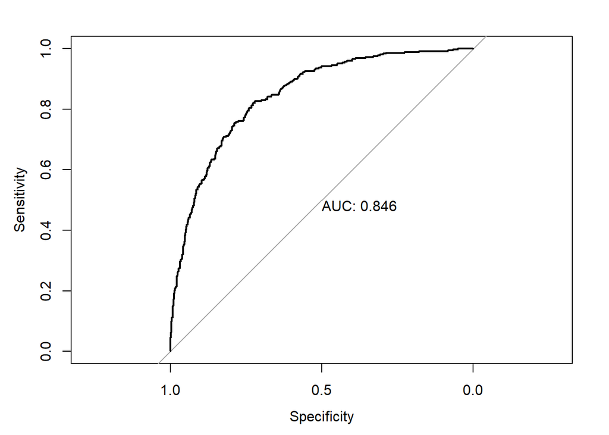

```
Call:
roc.default(response = Default_thresholds$Actual_defaults, predictor = Default_thresholds3$Probability_Left3,     plot = TRUE, print.auc = TRUE)

Data: Default_thresholds3$Probability_Left3 in 1053 controls (Default_thresholds$Actual_defaults Current) < 346 cases (Default_thresholds$Actual_defaults Left).
Area under the curve: 0.8464
```

```r
## Plot ROC baesd on threshold of 0.5

# We can do it by accessing the list object *Default_pred*. We first use the name *posterior* within bouble braces to access the matrix and then refer to the second column of the matrix using the square brackets.

Probability_Left3 <- Default_pred3[["posterior"]][,2]

# * We then save it as a dataframe and then also add the actual default values from the original dataset.

Default_thresholds3 <- data.frame(Probability_Left3)
Default_thresholds$Actual_defaults <- df.test$Status

# We now add another column and assign classes based on the threshold of 50%. If the posterior is > 0.5 then we assign a "Left" , else "Current".

Default_thresholds3 <- Default_thresholds3 %>%
  mutate(Class_th_0.5 = ifelse(Probability_Left3 > 0.5, "Left", "Current"), Class_th_0.5 = factor(Class_th_0.5, levels=c("Left", "Current")))

roc(Default_thresholds$Actual_defaults,Default_thresholds3$Probability_Left3,plot=TRUE,print.auc=TRUE)
```

## Model with these as predictor variable;

## Gender , SeniorCitizen , Partner , Dependents , PhoneService , MultipleLines , OnlineSecurity , OnlineBackup , DeviceProtection , TechSupport , StreamingTV , StreamingMovies , PaymentMethod , MonthlyCharges , TotalCharges

```r
## Defining the model
Default_lda4 <- lda(Status ~ Gender + SeniorCitizen + Partner + Dependents + PhoneService + MultipleLines + OnlineSecurity + OnlineBackup + DeviceProtection + TechSupport + StreamingTV + StreamingMovies + PaymentMethod + MonthlyCharges + TotalCharges, data = df.train)
Default_lda
```

```
Call:
lda(Status ~ Gender + SeniorCitizen + Partner + Dependents +
    Tenure + PhoneService + MultipleLines + InternetService +
    OnlineSecurity + OnlineBackup + DeviceProtection + TechSupport +
    StreamingTV + StreamingMovies + Contract + PaperlessBilling +
    PaymentMethod + MonthlyCharges + TotalCharges, data = df.train)

Prior probabilities of groups:
  Current      Left
0.7303571 0.2696429

Group means:
        GenderMale SeniorCitizen1 PartnerYes DependentsYes   Tenure PhoneServiceYes MultipleLinesNo phone service MultipleLinesYes InternetServiceFiber optic InternetServiceNo OnlineSecurityNo internet service OnlineSecurityYes
Current  0.5083130      0.1312958  0.5310513     0.3496333 37.62054        0.902934                    0.09706601        0.4110024                  0.3501222         0.2743276                         0.2743276         0.3320293
Left     0.4986755      0.2609272  0.3529801     0.1715232 18.10662        0.910596                    0.08940397        0.4490066                  0.6933775         0.0615894                         0.0615894         0.1536424
        OnlineBackupNo internet service OnlineBackupYes DeviceProtectionNo internet service DeviceProtectionYes TechSupportNo internet service TechSupportYes StreamingTVNo internet service StreamingTVYes StreamingMoviesNo internet service
Current                       0.2743276       0.3699267                           0.2743276           0.3594132                      0.2743276      0.3356968                      0.2743276      0.3674817                          0.2743276
Left                          0.0615894       0.2774834                           0.0615894           0.2913907                      0.0615894      0.1688742                      0.0615894      0.4377483                          0.0615894
        StreamingMoviesYes ContractOne year ContractTwo year PaperlessBillingYes PaymentMethodCredit card (automatic) PaymentMethodElectronic check PaymentMethodMailed check MonthlyCharges TotalCharges
Current          0.3687042       0.25085575       0.31931540           0.5352078                            0.2545232                     0.2493888                 0.2491443       61.32687     2553.577
Left             0.4397351       0.09072848       0.02649007           0.7483444                            0.1158940                     0.5754967                 0.1655629       74.43023     1548.337

Coefficients of linear discriminants:
                                               LD1
GenderMale                           -0.0155871185
SeniorCitizen1                        0.1875804273
PartnerYes                           -0.0341481971
DependentsYes                        -0.1224496155
Tenure                               -0.0106380734
PhoneServiceYes                      -0.1224374500
MultipleLinesNo phone service         0.1224374500
MultipleLinesYes                      0.2425690784
InternetServiceFiber optic            0.7861201964
InternetServiceNo                    -0.0935184099
OnlineSecurityNo internet service    -0.0935184099
OnlineSecurityYes                    -0.2991871368
OnlineBackupNo internet service      -0.0935184099
OnlineBackupYes                      -0.1201547777
DeviceProtectionNo internet service  -0.0935184099
DeviceProtectionYes                  -0.0116473734
TechSupportNo internet service       -0.0935184099
TechSupportYes                       -0.2604211380
StreamingTVNo internet service       -0.0935184099
StreamingTVYes                        0.1775665189
StreamingMoviesNo internet service   -0.0935184099
StreamingMoviesYes                    0.2271890199
ContractOne year                     -0.5048148786
ContractTwo year                     -0.3484916483
PaperlessBillingYes                   0.2277576278
PaymentMethodCredit card (automatic) -0.1027930181
PaymentMethodElectronic check         0.3306786935
PaymentMethodMailed check            -0.0553735159
MonthlyCharges                        0.0032672328
TotalCharges                         -0.0002019895
```

```r
## Confusion matrix
### Making predictions

Default_pred4 <- predict(Default_lda4,df.test)
head(Default_pred4$posterior)
```

```
     Current      Left
1  0.6095195 0.3904805
2  0.8988183 0.1011817
3  0.8223572 0.1776428
5  0.2372111 0.7627889
11 0.8749482 0.1250518
21 0.3906658 0.6093342
```

```r
### Make confusion matrix
Default_conf_matrix4 <- confusionMatrix(Default_pred4$class, df.test$Status, positive = "Left")
Default_conf_matrix4
```

```
Confusion Matrix and Statistics

          Reference
Prediction Current Left
   Current     946  161
   Left        107  185

               Accuracy : 0.8084
                 95% CI : (0.7868, 0.8287)
    No Information Rate : 0.7527
    P-Value [Acc > NIR] : 0.0000004045

                  Kappa : 0.457

 Mcnemar's Test P-Value : 0.001206

            Sensitivity : 0.5347
            Specificity : 0.8984
         Pos Pred Value : 0.6336
         Neg Pred Value : 0.8546
             Prevalence : 0.2473
         Detection Rate : 0.1322
   Detection Prevalence : 0.2087
      Balanced Accuracy : 0.7165

       'Positive' Class : Left
```

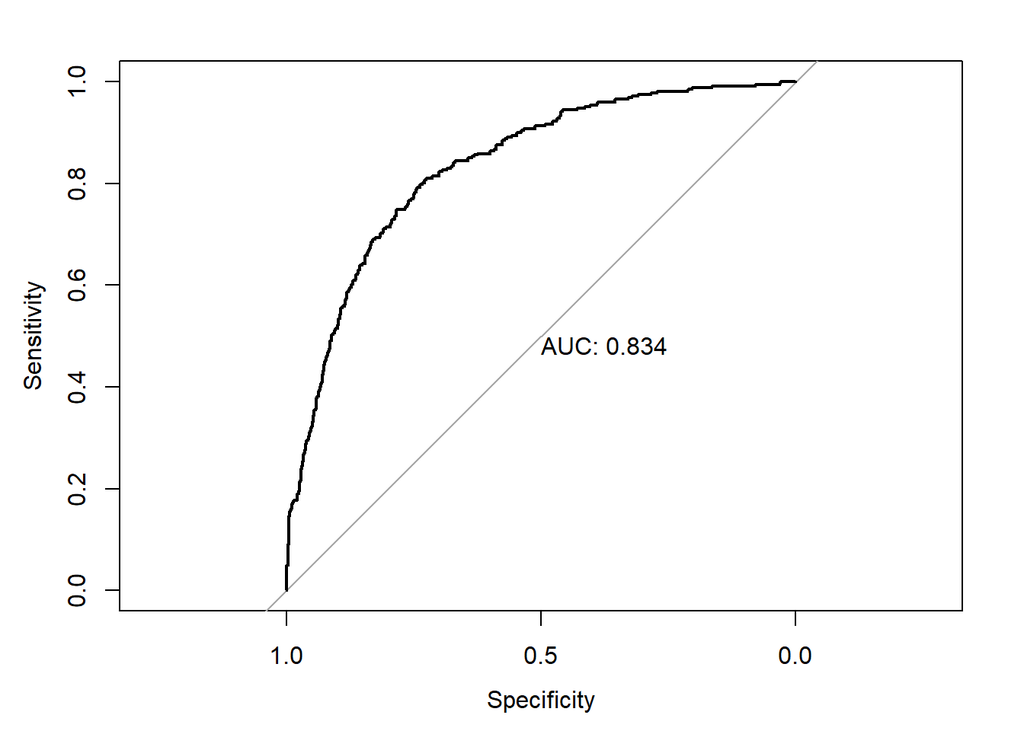

```
Call:
roc.default(response = Default_thresholds$Actual_defaults, predictor = Default_thresholds4$Probability_Left4,     plot = TRUE, print.auc = TRUE)

Data: Default_thresholds4$Probability_Left4 in 1053 controls (Default_thresholds$Actual_defaults Current) < 346 cases (Default_thresholds$Actual_defaults Left).
Area under the curve: 0.834
```

```r
## Plot ROC baesd on threshold of 0.5

# We can do it by accessing the list object *Default_pred*. We first use the name *posterior* within bouble braces to access the matrix and then refer to the second column of the matrix using the square brackets.

Probability_Left4 <- Default_pred4[["posterior"]][,2]

# * We then save it as a dataframe and then also add the actual default values from the original dataset.

Default_thresholds4 <- data.frame(Probability_Left4)
Default_thresholds$Actual_defaults <- df.test$Status

# We now add another column and assign classes based on the threshold of 50%. If the posterior is > 0.5 then we assign a "Left" , else "Current".

Default_thresholds4 <- Default_thresholds4 %>%
  mutate(Class_th_0.5 = ifelse(Probability_Left4 > 0.5, "Left", "Current"), Class_th_0.5 = factor(Class_th_0.5, levels=c("Left", "Current")))

roc(Default_thresholds$Actual_defaults,Default_thresholds4$Probability_Left4,plot=TRUE,print.auc=TRUE)
```

*OBSERVATION:*The AUC is 0.834

- For the model with the highest AUC, try different thresholds to identify the threshold with the highest prediction accuracy on the test set. ## Plot ROC baesd on threshold of 0.3

```r
# We can do it by accessing the list object *Default_pred*. We first use the name *posterior* within bouble braces to access the matrix and then refer to the second column of the matrix using the square brackets.

Probability_Left <- Default_pred[["posterior"]][,2]

# * We then save it as a dataframe and then also add the actual default values from the original dataset.

Default_thresholds <- data.frame(Probability_Left)
Default_thresholds$Actual_defaults <- df.test$Status

# We now add another column and assign classes based on the threshold of 50%. If the posterior is > 0.5 then we assign a "Left" , else "Current".

Default_thresholds <- Default_thresholds %>%
  mutate(Class_th_0.3 = ifelse(Probability_Left > 0.3, "Left", "Current"), Class_th_0.3 = factor(Class_th_0.3, levels=c("Left", "Current")))

confusionMatrix(Default_thresholds$Class_th_0.3, Default_thresholds$Actual_defaults, positive = "Left")
```

```
Confusion Matrix and Statistics

          Reference
Prediction Current Left
   Current     839   80
   Left        214  266

               Accuracy : 0.7898
                 95% CI : (0.7675, 0.8109)
    No Information Rate : 0.7527
    P-Value [Acc > NIR] : 0.0005905

                  Kappa : 0.5005

 Mcnemar's Test P-Value : 0.000000000000008716

            Sensitivity : 0.7688
            Specificity : 0.7968
         Pos Pred Value : 0.5542
         Neg Pred Value : 0.9129
             Prevalence : 0.2473
         Detection Rate : 0.1901
   Detection Prevalence : 0.3431
      Balanced Accuracy : 0.7828

       'Positive' Class : Left
```